# Final Project Example

2025-12-04

#### Term Project Description

This document is a final project for the UCSD Course BILD 5. My project builds upon the study referenced below. I have proposed a potential follow-up experiment to extend the study’s findings. The project utilizes simulated data, structured and analyzed as if collected from a real experiment. While the outcomes do not provide scientific evidence, they showcase my skills in formulating and addressing relevant biological questions through statistics, experimental design, and programming.

#### Article Citation

Ogawa, M. (2021). Relationship between oral health and physical frailty in patients with cardiovascular disease. Journal of Cardiology, 77(2), 131–138.

#### Research Question

How Type of Coca Cola intake (Control, Original, Diet Coke) Relates to Relative Enamel Calcium Index?

#### Null Hypothesis

Null hypothesis is that average of Relative Enamel Calcium Index from each group is equal to the overall mean of Enamel Calcium Index.

#### Alternate Hypothesis

Alternate Hypothesis is that at least one group’s predicted value of Relative Enamel Calcium Index differs from the mean of Enamel Calcium Index.

#### Test Performed

I will perform ANOVA, as there are 3 groups of continuous data Enamel Calcium Index.

#### Import and Tidy the Data

```
## tibble [90 × 2] (S3: tbl_df/tbl/data.frame)
##  $ Groups                    : chr [1:90] "Control" "Original" "Diet" "Control" ...
##  $ RelativeEnamelCalciumIndex: num [1:90] 84.5 39.2 50 67.6 29.3 ...
```

#### Exploratory Data Analysis

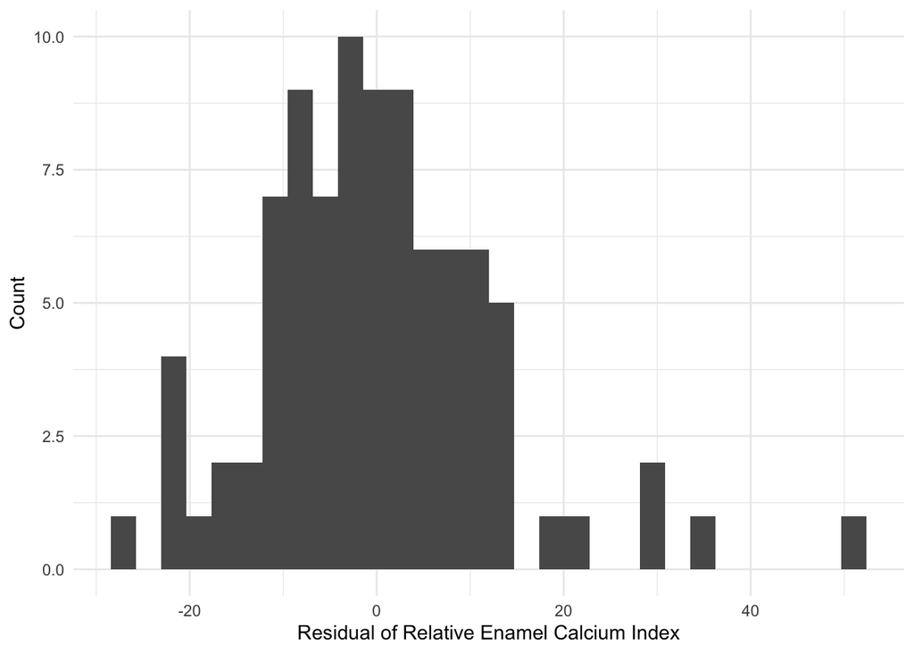

```
##
##  Exact one-sample Kolmogorov-Smirnov test
##
## data:  Residual
## D = 0.07398, p-value = 0.6802
## alternative hypothesis: two-sided
```

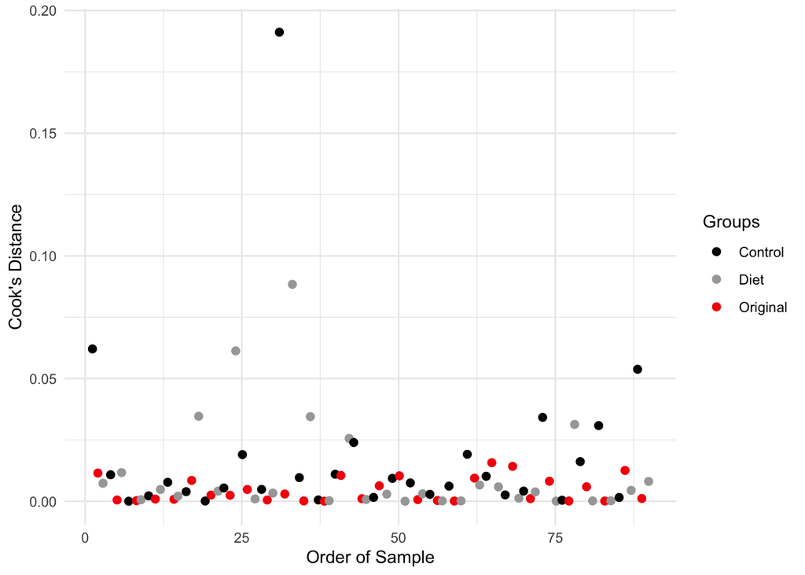

#### Description of Current Data and Plan for Fixes if Needed

I did the ks test and the p value indicates that residual distribution is normal. Then the cooks distance scatter graph shows there is no outliers. My data is very good.

#### Correct Data Issues and Build Final Data Table.

From the K-S test, we can observe that the residuals are normally distributed, as p value is greater than 0.05. On the Cook’s distance plot, we can see all residuals have a cook’s distance less than 0.2. This Data is neither skewed nor has outlier. Thus there is no need to do extra process to this data frame.

```
## tibble [90 × 2] (S3: tbl_df/tbl/data.frame)
##  $ Groups                    : chr [1:90] "Control" "Original" "Diet" "Control" ...
##  $ RelativeEnamelCalciumIndex: num [1:90] 84.5 39.2 50 67.6 29.3 ...
```

#### Test the Null Hypothesis of Your Research Question

```r
summary(m1)
```

```
##
## Call:
## lm(formula = RelativeEnamelCalciumIndex ~ Groups, data = TIDY_DF)
##
## Residuals:
##     Min      1Q  Median      3Q     Max
## -27.062  -7.509  -1.259   6.656  51.015
##
## Coefficients:
##                Estimate Std. Error t value Pr(>|t|)
## (Intercept)      55.456      2.323  23.873  < 2e-16 ***
## GroupsDiet      -15.495      3.285  -4.717 9.07e-06 ***
## GroupsOriginal  -28.771      3.285  -8.758 1.41e-13 ***
## ---
## Signif. codes:  0 '***' 0.001 '**' 0.01 '*' 0.05 '.' 0.1 ' ' 1
##
## Residual standard error: 12.72 on 87 degrees of freedom
## Multiple R-squared:  0.469,  Adjusted R-squared:  0.4568
## F-statistic: 38.43 on 2 and 87 DF,  p-value: 1.098e-12
```

```r
post_hoc<-aov(RelativeEnamelCalciumIndex~Groups, Corrected_TIDY_DF)
TukeyHSD(post_hoc)
```

```
##   Tukey multiple comparisons of means
##     95% family-wise confidence level
##
## Fit: aov(formula = RelativeEnamelCalciumIndex ~ Groups, data = Corrected_TIDY_DF)
##
## $Groups
##                       diff       lwr        upr     p adj
## Diet-Control     -15.49457 -23.32799  -7.661161 0.0000269
## Original-Control -28.77093 -36.60434 -20.937518 0.0000000
## Original-Diet    -13.27636 -21.10977  -5.442944 0.0003341
```

#### Build the Figure That Best Tells the Story of Your Model

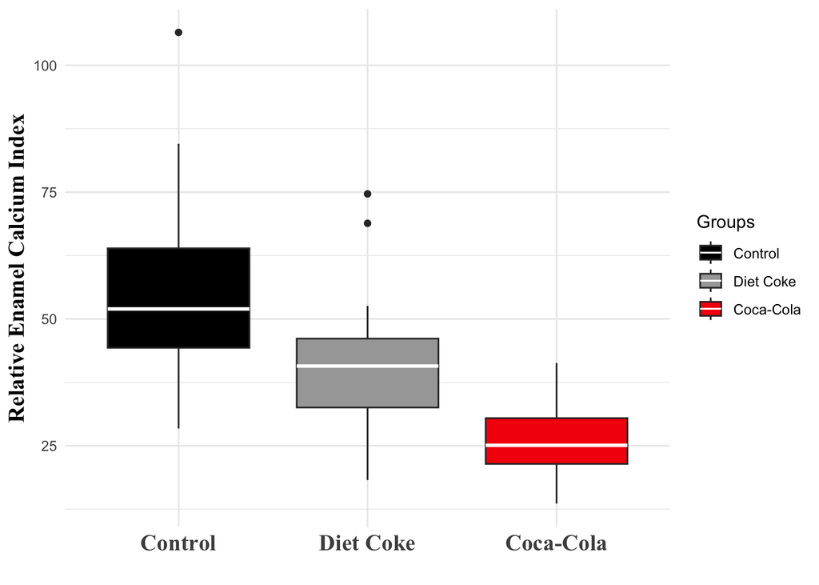

#### Figure Caption

From the ANOVA test we can tell the F statistic shows 38.43 with degree of freedom of 2 (group) and 87 (sample). p value is 1.098e-12 and therefore Null hypothesis is rejected. at least one group have group-wide mean different from the whole sample mean. Then post-hoc test is done using TukeyHSD. the result form TukeyHSD tells us all three groups are different from each other, as all three sets of data has a p value less than 0.05, so null hypothesis (of the mean of two groups are equal) is rejected. From the graph, indicate that both Coca-Cola and Diet Coke significantly reduce enamel calcium. Moreover, Coca-Cola caused significantly greater mineral loss than Diet Coke, suggesting that regular Coca-Cola is more damaging to enamel than Diet Coke.